# Week13_Wednesday slides

## Week 13 Wednesday

Wednesday, April 22

**Announcements**

- A09 Assigned: Due Monday, May 4
- A10 Assigned: Due Friday, May 8

**Goals**

- Introduction to probabilistic occupancy: Part 1
- Continue vision-based reconstruction of green ball pose
- Begin work on Final project

#### Measurements and Predictions of Location: Occupancy

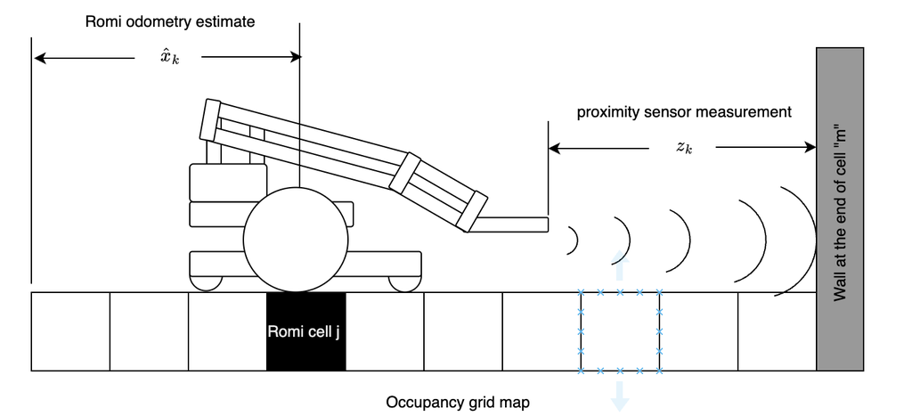

#### Measurements and Predictions of Location: Occupancy

- We've learned to estimate what cell $j$ the Romi occupies:
  - $j = int(\frac{m}{D}(\hat{x}_k - \frac{D}{2m}))$
    - $\hat{x}_k$ is an *estimate* of Romi position that could come from a *measurement* $z_k$ **OR** a model-based prediction of Romi motion given inputs.
  - All we can do right now is use *either* a measurement *or* a prediction, and say that the cell occupancy $j$ is "certain" based on one or the other.
  - Could we improve this approach by acknowledging uncertainty in measurements and predictions? Maybe combine both?

#### Probabilistic Occupancy Grids

(notes are adapted from ["Probabilistic Robotics" by Thrun, Burgard, & Fox](https://mitpress.mit.edu/9780262201629/probabilistic-robotics/))

- Instead of a Boolean "1" or "0" in our grid, let's make our grid occupancy a number representing the probability or **Belief** that our Romi is there.

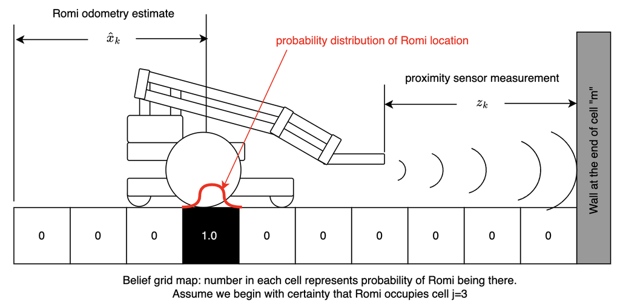

#### "Updating" our Belief based on uncertainty changes the grid

- If our model for Romi motion predicts that we are still in cell j=3 after one timestep, how does our belief change?

[figure not shown]

#### What happens after a second timestep?

- Say that after one more timestep, we know that the model predicts we are now in cell j=4.

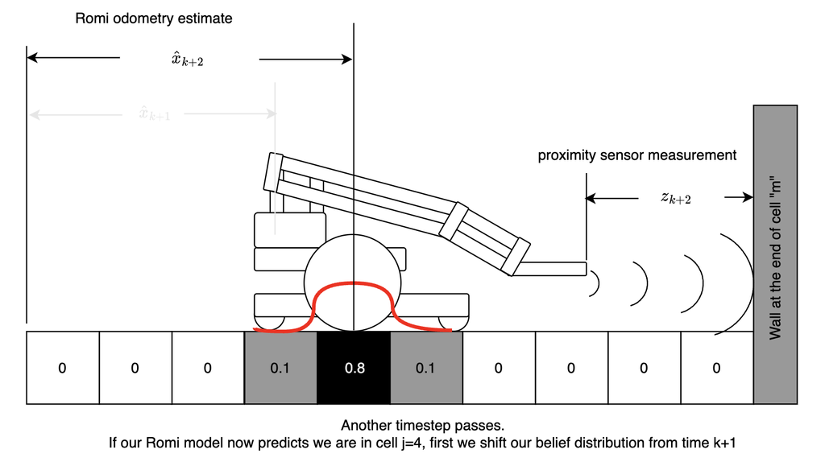

#### But now, we realize that this prediction is *also* uncertain!

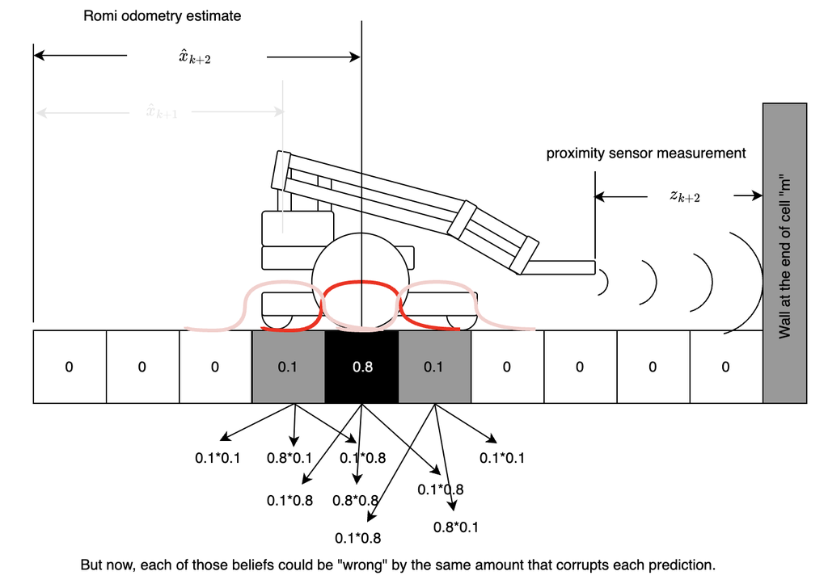

#### But now, we realize that this prediction is *also* uncertain!

[figure not shown]

## This idea relies on some (big) assumptions...

- Prediction of time k *only* relies on state at time k-1 and inputs. "Markov Assumption"
- Noise (uncertainty) is statistically independent from timestep to timestep
- This allows us to apply the rules of probability for independent measurements to understand how our belief evolves from timestep to timestep.

### Terminology

- $P(a)\rightarrow$ probability of a occurring
- $P(b)\rightarrow$ probability of b occurring
- $P(a,b)\rightarrow$ probability of a and b occurring
- $P(a|b)\rightarrow$ probability of event a occurring given that b has occurred

### Rules for statistically independent events a and b

- $P(a,b) = P(a) \cdot P(b)$ if a and b are statistically independent
- $P(a|b) = P(a,b)$

### What is a statistically independent set of events?

The probability of a fair coin flip is 50% heads, 50% tails. What is the probability of 2 heads in a row? $$P(h|h) = P(h,h) = P(h)\cdot P(h)=0.5\cdot0.5 = 0.25$$

## What does this mean for our prior example?

> We have to consider uncertainty in our belief about the occupancy of each cell in the grid. If we believed that there was >0% chance the robot could have occupied a grid cell at the last timestep, we have to consider that this uncertainty is compounded every time I update my model, since it could have overpredicted or underpredicted the true motion of the robot *again*.

[figure not shown]

If we had a 80% belief in cell 4 before, we are less certain now after updating our model, since it is uncertain.

- "a" represents probability that j=4 at time k
- "b" represents probability that j=4 at time k-1

$$P(a|b)=P(a)\cdot P(b) = 0.8\cdot0.8 = 0.64$$

But this is just based on being "right," not based on under or over-predicting. We could also get j=4 by overpredicting from from a true robot position in cell j=3, or under-predicting from a true robot position in cell 5.

[figure not shown]

#### To consider probability from all sources of error

This can be written compactly for belief in any cell $j$ using a PDF $H$ with length $n$ as: $$Bel(j)_k = \sum_{i=0}^{n-1} H(i)\cdot Bel\left(j+i-\frac{n-1}{2}\right)_{k-1}$$

[figure not shown]

#### This is an equation for convolution!

$$Bel(j)_k = \sum_{i=0}^{n-1} H(i)\cdot Bel\left(j+i-\frac{n-1}{2}\right)_{k-1}$$

our PDF $H$ is a "kernel" that we convolve over the prior belief to obtain an updated belief that accounts for the additional uncertainty in our latest prediction. As time goes on, we get more and more uncertain.

**How do we fix this? Using measurements to reduce uncertainty!**

## Class Exercise

In the Week12_InClass world, the Romi is equipped with a camera. Inside the controller file, you are already presented with the methodology to read camera frames in Webots.

1. Allow the Romi to explore using an explore FSM unless it sees a ball.
2. Once a ball is in frame, use a feedback controller to "aim" (angle in yaw) the Romi so that the center of the ball is in the center of the image.
3. Measure the **distance from the Romi (not the camera!) to the ball!** Compare this with "ground truth" distance measurements from a supervisor, or from a GPS measurement of Romi position and a known ball location.

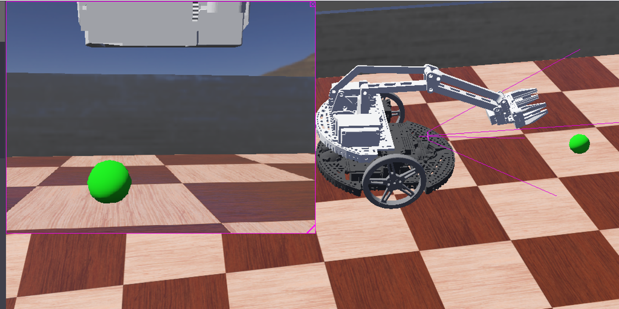